# Heart Disease Dataset

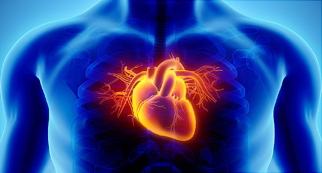

### Ejercicios:

1 - Lectura del dataset

**1.1** Visualiza las primeras 5 filas y las últimas 5 filas de tu dataset

```python
import pandas as pd
heart_df = pd.read_csv("../Datos/heart.csv")
heart_df
```

|  | age | sex | cp | trestbps | chol | fbs | restecg | thalach | exang | oldpeak | slope | ca | thal | target |
| --- | --- | --- | --- | --- | --- | --- | --- | --- | --- | --- | --- | --- | --- | --- |
| 0 | 52 | 1 | 0 | 125 | 212 | 0 | 1 | 168 | 0 | 1.0 | 2 | 2 | 3 | 0 |
| 1 | 53 | 1 | 0 | 140 | 203 | 1 | 0 | 155 | 1 | 3.1 | 0 | 0 | 3 | 0 |
| 2 | 70 | 1 | 0 | 145 | 174 | 0 | 1 | 125 | 1 | 2.6 | 0 | 0 | 3 | 0 |
| 3 | 61 | 1 | 0 | 148 | 203 | 0 | 1 | 161 | 0 | 0.0 | 2 | 1 | 3 | 0 |
| 4 | 62 | 0 | 0 | 138 | 294 | 1 | 1 | 106 | 0 | 1.9 | 1 | 3 | 2 | 0 |
| ... | ... | ... | ... | ... | ... | ... | ... | ... | ... | ... | ... | ... | ... | ... |
| 1020 | 59 | 1 | 1 | 140 | 221 | 0 | 1 | 164 | 1 | 0.0 | 2 | 0 | 2 | 1 |
| 1021 | 60 | 1 | 0 | 125 | 258 | 0 | 0 | 141 | 1 | 2.8 | 1 | 1 | 3 | 0 |
| 1022 | 47 | 1 | 0 | 110 | 275 | 0 | 0 | 118 | 1 | 1.0 | 1 | 1 | 2 | 0 |
| 1023 | 50 | 0 | 0 | 110 | 254 | 0 | 0 | 159 | 0 | 0.0 | 2 | 0 | 2 | 1 |
| 1024 | 54 | 1 | 0 | 120 | 188 | 0 | 1 | 113 | 0 | 1.4 | 1 | 1 | 3 | 0 |

1025 rows × 14 columns

**1.2** Visualiza la información de tu dataset

```python
heart_df.info()
```

```
<class 'pandas.core.frame.DataFrame'>
RangeIndex: 1025 entries, 0 to 1024
Data columns (total 14 columns):
 #   Column    Non-Null Count  Dtype
---  ------    --------------  -----
 0   age       1025 non-null   int64
 1   sex       1025 non-null   int64
 2   cp        1025 non-null   int64
 3   trestbps  1025 non-null   int64
 4   chol      1025 non-null   int64
 5   fbs       1025 non-null   int64
 6   restecg   1025 non-null   int64
 7   thalach   1025 non-null   int64
 8   exang     1025 non-null   int64
 9   oldpeak   1025 non-null   float64
 10  slope     1025 non-null   int64
 11  ca        1025 non-null   int64
 12  thal      1025 non-null   int64
 13  target    1025 non-null   int64
dtypes: float64(1), int64(13)
memory usage: 112.2 KB
```

**1.3** Obten información estadística del dataset con la función describe

```python
heart_df.describe()
```

|  | age | sex | cp | trestbps | chol | fbs | restecg | thalach | exang | oldpeak | slope | ca | thal | target |
| --- | --- | --- | --- | --- | --- | --- | --- | --- | --- | --- | --- | --- | --- | --- |
| count | 1025.000000 | 1025.000000 | 1025.000000 | 1025.000000 | 1025.00000 | 1025.000000 | 1025.000000 | 1025.000000 | 1025.000000 | 1025.000000 | 1025.000000 | 1025.000000 | 1025.000000 | 1025.000000 |
| mean | 54.434146 | 0.695610 | 0.942439 | 131.611707 | 246.00000 | 0.149268 | 0.529756 | 149.114146 | 0.336585 | 1.071512 | 1.385366 | 0.754146 | 2.323902 | 0.513171 |
| std | 9.072290 | 0.460373 | 1.029641 | 17.516718 | 51.59251 | 0.356527 | 0.527878 | 23.005724 | 0.472772 | 1.175053 | 0.617755 | 1.030798 | 0.620660 | 0.500070 |
| min | 29.000000 | 0.000000 | 0.000000 | 94.000000 | 126.00000 | 0.000000 | 0.000000 | 71.000000 | 0.000000 | 0.000000 | 0.000000 | 0.000000 | 0.000000 | 0.000000 |
| 25% | 48.000000 | 0.000000 | 0.000000 | 120.000000 | 211.00000 | 0.000000 | 0.000000 | 132.000000 | 0.000000 | 0.000000 | 1.000000 | 0.000000 | 2.000000 | 0.000000 |
| 50% | 56.000000 | 1.000000 | 1.000000 | 130.000000 | 240.00000 | 0.000000 | 1.000000 | 152.000000 | 0.000000 | 0.800000 | 1.000000 | 0.000000 | 2.000000 | 1.000000 |
| 75% | 61.000000 | 1.000000 | 2.000000 | 140.000000 | 275.00000 | 0.000000 | 1.000000 | 166.000000 | 1.000000 | 1.800000 | 2.000000 | 1.000000 | 3.000000 | 1.000000 |
| max | 77.000000 | 1.000000 | 3.000000 | 200.000000 | 564.00000 | 1.000000 | 2.000000 | 202.000000 | 1.000000 | 6.200000 | 2.000000 | 4.000000 | 3.000000 | 1.000000 |

**1.4** obten las dimensiones del dataset

```python
heart_df.shape # (filas, columnas)
```

```
(1025, 14)
```

**1.5** Asegura que tu dataset no contega valores nulos con la funcion isnull()

```python
heart_df.isnull().sum()   # Para obtener el resumen de todas las variables hacemos un sum() (Summary o resumen)
```

```
age         0
sex         0
cp          0
trestbps    0
chol        0
fbs         0
restecg     0
thalach     0
exang       0
oldpeak     0
slope       0
ca          0
thal        0
target      0
dtype: int64
```

2 - Exploración de los datos

**2.1** Realizar un mapa de calor para visualizar las correlaciones entre características

```python
# Para comprobar la correlación de forma numerica sería heart_df.corr()
import matplotlib.pyplot as plt
import seaborn as sns
%config InlineBackend.figure_formats = ['svg']
plt.rcParams['svg.fonttype'] = 'none'


sns.heatmap(heart_df.corr(), cmap="Blues")
```

[figure not shown]

3 - Preparación de los datos

**3.2** Dividir el dataset en conjunto de entrenamiento (train) y conjunto de test (test)

```python
from sklearn.model_selection import train_test_split # Para dividir el dataset en el conjunto de entrenamiento y test
df_train, df_test = train_test_split(heart_df, test_size = 0.3)
```

**3.1** Dividir el dataset en (X,y)

```python
train_X = df_train.drop(['target'], axis=1)
train_y=pd.DataFrame(df_train['target'])
test_X= df_test.drop(['target'], axis=1)
test_y =pd.DataFrame(df_test['target'])
```

4 - Selección de Modelos

**4.1** Implementar varios modelos de clasificación

```python
from sklearn.neighbors import KNeighborsClassifier    # KNeighborsClassifier
knn = KNeighborsClassifier(n_neighbors=1)
```

```python
from sklearn import tree
clf = tree.DecisionTreeClassifier()                   # DecisionTreeClassifier
```

5 - Evaluación de Modelos

**5.1** Entrenar y validar todos los modelos con las métricas de evaluacion vistas en clase

```python
from sklearn.metrics import accuracy_score   # Usare accuracy_score para la evaluacion
```

```python
import warnings
warnings.filterwarnings('ignore')

knn.fit(train_X,train_y)

from sklearn.metrics import *
prediction=knn.predict(test_X)
print('KNN Model :',accuracy_score(prediction,test_y))
```

```
KNN Model : 0.9675324675324676
```

```python
clf = clf.fit(train_X,train_y)
prediccion = clf.predict(test_X)
print('CLF Model :',accuracy_score(prediccion,test_y))
```

```
CLF Model : 0.987012987012987
```

**5.2** Comparar las métricas de cada uno de los modelos y seleccionar el mejor

Viendo la dos metricas `0.97` y `0.99` La segunda que es la del algoritmo `DecisionTree` es la que mejor se adapta en cuanto al accuracy